# Exercises week 36

## Deriving and Implementing Ridge Regression

## Learning goals

After completing these exercises, you will know how to

- Take more derivatives of simple products between vectors and matrices
- Implement Ridge regression using the analytical expressions
- Scale data appropriately for linear regression
- Evaluate a model across two different hyperparameters

## Exercise 1 - Choice of model and degrees of freedom

**a)** How many degrees of freedom does an OLS model fit to the features $x, x^2, x^3$ and the intercept have?

**b)** Why is it bad for a model to have too many degrees of freedom?

**c)** Why is it bad for a model to have too few degrees of freedom?

**d)** Read [chapter 3.4.1 of Hastie et al.'s book](https://link.springer.com/book/10.1007/978-0-387-84858-7). What is the expression for the effective degrees of freedom of the ridge regression fit?

**e)** Why might we want to use Ridge regression instead of OLS?

**f)** Why migth we want to use OLS instead of Ridge regression?

## Exercise 1 - Answers

**a)** An OLS model fit to the features $x$, $x^2$, $x^3$ and the intercept will have parameters $\theta _1, ..., \theta _4$. So the model including the intercept has 4 degrees of freedom.

**b)** Too many degrees of freedom can cause a variety of issues. The most important issues are overfitting and interpretability loss. Overfitting causes a model to be a perfect fit for the training data, but nothing is generalized from the data. So if we want to predict data that is not in the training data, we can get a huge prediction error. Interpretability loss means that if we have many parameters (degrees of freedom), it is difficult to interpret the physical meaning of each parameter.

**c)** Too few degrees of freedom can cause underfitting. This means that the model is biased, so predictions are systematically wrong in the same direction. The model is too simple to capture the structure of the data. This means that the model does not explain enough.

**d)** The expression for the effective degrees of freedom of the ridge regression fit is: $$ df(\lambda) = \sum_{j=1}^{p}\frac{d_j^2}{d_j^2 + \lambda}, $$ where $d_j^2$ are the eigenvalues (squared singular values) of X. This expression does not include the intercept, so if we include the intercept, the expression becomes: $$ (\sum_{j=1}^{p}\frac{d_j^2}{d_j^2 + \lambda} )+ 1 $$

**e)** There are multiple reasons. Ridge regression intruduces an extra element on the diagonal on the matrix $(X^TX)$, so the matrix becomes non-singular and you can compute its inverse. In addition, Ridge regression controls overfitting.

**f)** The OLS gives an unbiased estimate, while the Ridge regression are biased (variance/bias-tradeoff). In addition, the parameters in OLS are easy and intuitive to interpret.

## Exercise 2 - Deriving the expression for Ridge Regression

The aim here is to derive the expression for the optimal parameters using Ridge regression.

The expression for the standard Mean Squared Error (MSE) which we used to define our cost function and the equations for the ordinary least squares (OLS) method, was given by the optimization problem

$$ {\displaystyle \min_{\boldsymbol{\beta}\in {\mathbb{R}}^{p}}}\frac{1}{n}\left\{\left(\boldsymbol{y}-\boldsymbol{X}\boldsymbol{\beta}\right)^T\left(\boldsymbol{y}-\boldsymbol{X}\boldsymbol{\beta}\right)\right\}. $$

By minimizing the above equation with respect to the parameters $\boldsymbol{\beta}$ we could then obtain an analytical expression for the parameters $\boldsymbol{\hat\beta_{OLS}}$.

We can add a regularization parameter $\lambda$ by defining a new cost function to be optimized, that is

$$ {\displaystyle \min_{\boldsymbol{\beta}\in {\mathbb{R}}^{p}}}\frac{1}{n}\vert\vert \boldsymbol{y}-\boldsymbol{X}\boldsymbol{\beta}\vert\vert_2^2+\lambda\vert\vert \boldsymbol{\beta}\vert\vert_2^2 $$

which leads to the Ridge regression minimization problem. (One can require as part of the optimization problem that $\vert\vert \boldsymbol{\beta}\vert\vert_2^2\le t$, where $t$ is a finite number larger than zero. We will not implement that in this course.)

### a) Expression for Ridge regression

Show that the optimal parameters

$$ \hat{\boldsymbol{\beta}}_{\mathrm{Ridge}} = \left(\boldsymbol{X}^T\boldsymbol{X}+\lambda\boldsymbol{I}\right)^{-1}\boldsymbol{X}^T\boldsymbol{y}, $$

with $\boldsymbol{I}$ being a $p\times p$ identity matrix.

The ordinary least squares result is

$$ \hat{\boldsymbol{\beta}}_{\mathrm{OLS}} = \left(\boldsymbol{X}^T\boldsymbol{X}\right)^{-1}\boldsymbol{X}^T\boldsymbol{y}, $$

## Exercise 2 - Answers

**a)** We start by defining the cost function as: $$ C(\boldsymbol{X}, \boldsymbol{\beta}) = \frac{1}{n} \vert \vert \boldsymbol{y} - \boldsymbol{X\beta}\vert \vert _2 ^2 + \lambda\vert\vert\boldsymbol{\beta}\vert\vert _2 ^2 $$ We then use the definition of the 2-norm to rewrite the cost function as: $$ C(\boldsymbol{X}, \boldsymbol{\beta}) = \frac{1}{n} (\sum_i(y_i - (X\beta)_i)^2 )+ \lambda \sum_i\beta _i ^2 = \frac{1}{n}((\boldsymbol{y}-\boldsymbol{X\beta})^T(\boldsymbol{y}-\boldsymbol{X\beta})) + \lambda\beta ^T \beta $$

Now, we want to differentiate with respect to $\beta$. We use the following result from last weeks exercise: $$ \frac{\partial \left(\boldsymbol{x}-\boldsymbol{A}\boldsymbol{s}\right)^T\left(\boldsymbol{x}-\boldsymbol{A}\boldsymbol{s}\right)}{\partial \boldsymbol{s}} = -2\left(\boldsymbol{x}-\boldsymbol{A}\boldsymbol{s}\right)^T\boldsymbol{A}. $$ Differentiating gives: $$ \frac{\partial C}{\partial \boldsymbol{\beta}}=\frac{\partial}{\partial\boldsymbol\beta}(\frac{1}{n}((\boldsymbol{y}-\boldsymbol{X\beta})^T(\boldsymbol{y}-\boldsymbol{X\beta})) + \lambda\beta ^T \beta) = \frac{1}{n}(-2(\boldsymbol{y}-\boldsymbol{X\beta})^T\boldsymbol{X}) + 2\lambda\boldsymbol{\beta}^T = -2(\frac{1}{n}(\boldsymbol{y}-\boldsymbol{X\beta})^T\boldsymbol{X}-\lambda\boldsymbol{\beta}^T) $$

We equate this to zero: $$ -2(\frac{1}{n}(\boldsymbol{y}-\boldsymbol{X\beta})^T\boldsymbol{X}-\lambda\boldsymbol{\beta}^T) = 0 $$ $$ \Rightarrow (\boldsymbol{y}-\boldsymbol{X\beta})^T\boldsymbol{X} - \lambda\boldsymbol{\beta}^T = 0, $$ where we now have omitted the $\frac{1}{n}$ term. We could have done this when we were defining the cost function. $$ \Rightarrow (\boldsymbol{y}-\boldsymbol{X\beta})^T\boldsymbol{X} = \lambda\boldsymbol{\beta}^T $$ $$ \Rightarrow (\boldsymbol{y}^T-\boldsymbol{\beta}^T\boldsymbol{X}^T)\boldsymbol{X}=\lambda\boldsymbol{\beta}^T $$ $$ \Rightarrow \boldsymbol{y}^T\boldsymbol{X} - \boldsymbol{\beta}^T\boldsymbol{X}^T\boldsymbol{X} = \lambda \boldsymbol{\beta}^T $$ Transposing both sides gives: $$ (\boldsymbol{y}^T\boldsymbol{X})^T - (\boldsymbol{\beta}^T\boldsymbol{X}^T\boldsymbol{X})^T = (\lambda\boldsymbol{\beta}^T)^T $$ $$ \Rightarrow \boldsymbol{X}^T\boldsymbol{y} - \boldsymbol{X}^T\boldsymbol{X}\boldsymbol{\beta} = \lambda \boldsymbol{\beta} $$ $$ \Rightarrow \boldsymbol{X}^T\boldsymbol{y} = \boldsymbol{X}^T\boldsymbol{X}\boldsymbol{\beta} + \lambda\boldsymbol{\beta} $$ $$ \Rightarrow \boldsymbol{X}^T\boldsymbol{y} = (\boldsymbol{X}^T\boldsymbol{X} + \lambda \boldsymbol{I})\boldsymbol{\beta}, $$ where the $p\times p$ identity matrix $\boldsymbol{I}$ ensures that $\lambda\boldsymbol{\beta}$ is treated as a matrix-vector multiplication. Inverting $(\boldsymbol{X}^T\boldsymbol{X} + \lambda \boldsymbol{I})$, and multiplying both sides by this inverse, gives: $$ \boldsymbol{\beta} = (\boldsymbol{X}^T\boldsymbol{X}+\lambda\boldsymbol{I})^{-1}\boldsymbol{X}^T\boldsymbol{y} $$

The matrix $(\boldsymbol{X}^T\boldsymbol{X} + \lambda \boldsymbol{I})$ is invertible because of the parameter $\lambda$ being added on to all diagonal elements.

## Exercise 3 - Scaling data

```python
import numpy as np
import matplotlib.pyplot as plt
from sklearn.model_selection import train_test_split
from sklearn.preprocessing import StandardScaler
```

```python
n = 100
x = np.linspace(-3, 3, n)
y = np.exp(-x**2) + 1.5 * np.exp(-(x-2)**2) + np.random.normal(0, 0.1)
```

**a)** Adapt your function from last week to only include the intercept column if the boolean argument `intercept` is set to true.

```python
def polynomial_features(x, p, intercept=False):
    n = len(x)
    # Condition on intercept:
    if intercept==True:
        X = np.zeros((n, p + 1))
        for i in range(p+1):
            X[:, i] = x ** i
            # First column becomes ones because for all x, x**i = 1 when i=0.
    else:
        X = np.zeros((n, p))
        for i in range(p):
            X[:, i] = x ** (i+1)

    return X
```

```python
#Printing feature matrix with and without intercept (testing)
"""
X_intercept = polynomial_features(x, 3, intercept=True)
X_notintercept = polynomial_features(x, 3)
print(X_intercept)
print(X_notintercept)
"""
```

```
'\nX_intercept = polynomial_features(x, 3, intercept=True)\nX_notintercept = polynomial_features(x, 3)\nprint(X_intercept)\nprint(X_notintercept)\n'
```

**b)** Split your data into training and test data(80/20 split)

```python
X = polynomial_features(x, 3)
```

```python
X_train, X_test, y_train, y_test = train_test_split(X, y, test_size=0.2)
x_train = X_train[:, 0] # These are used for plotting
x_test = X_test[:, 0] # These are used for plotting
```

**c)** Scale your design matrix with the sklearn standard scaler, though based on the mean and standard deviation of the training data only.

```python
scaler = StandardScaler()
scaler.fit(X_train)
X_train_s = scaler.transform(X_train)
X_test_s = scaler.transform(X_test)
y_offset = np.mean(y_train)
```

## Exercise 4 - Implementing Ridge Regression

**a)** Implement a function for computing the optimal Ridge parameters using the expression from **2a)**.

```python
def Ridge_parameters(X, y, lam = 1.0):
    # Assumes X is scaled and has no intercept column
    p = X.shape[1]
    return np.linalg.pinv((X.T @ X)+ lam*np.eye(p)) @ X.T @ y

beta = Ridge_parameters(X_train_s, y_train)
#print(beta)
```

**b)** Fit a model to the data, and plot the prediction using both the training and test x-values extracted before scaling, and the y_offset.

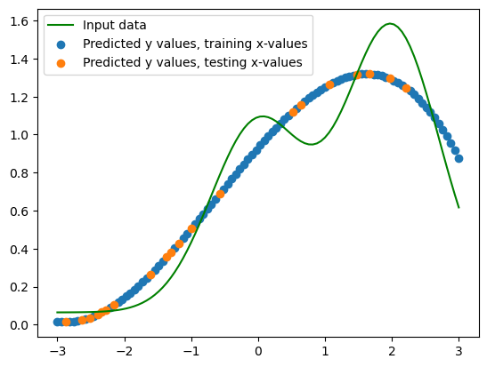

```python
plt.plot(x, y, label = "Input data", color="green")
plt.scatter(x_train, X_train_s @ beta + y_offset, label="Predicted y values, training x-values")
plt.scatter(x_test, X_test_s @ beta + y_offset, label="Predicted y values, testing x-values")
plt.legend()
plt.show()
```

## Exercise 5 - Testing multiple hyperparameters

**a)** Compute the MSE of your ridge model for polynomials of degrees 1 to 5 with lambda set to 0.01. Plot the MSE as a function of polynomial degree.

**b)** Compute the MSE of your ridge model for a polynomial with degree 3, and with lambdas from $10^{-1}$ to $10^{-5}$ on a logarithmic scale. Plot the MSE as a function of lambda.

**c)** Compute the MSE of your ridge model for polynomials of degrees 1 to 5, and with lambdas from $10^{-1}$ to $10^{-5}$ on a logarithmic scale. Plot the MSE as a function of polynomial degree and lambda using a [heatmap](https://matplotlib.org/stable/gallery/images_contours_and_fields/image_annotated_heatmap.html).

## Exercise 5 - Answers

**a)**

```
[0. 0. 0. 0. 0.]
```

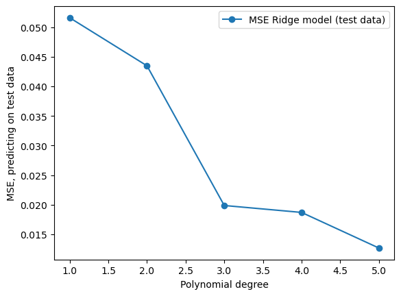

```python
from sklearn.metrics import mean_squared_error
# Define lambda and degrees
lam = 0.01
degrees = np.arange(1, 6)
# MSE computed on test data
MSE = np.zeros(len(degrees))
print(MSE)

# Split data (not splitting the feature matries as in the last task)
x_train, x_test, y_train, y_test = train_test_split(x, y, test_size=0.2)


for i in degrees:
    # Make feature matrices
    X_train = polynomial_features(x_train, i)
    X_test = polynomial_features(x_test, i)
    # Scale data
    scaler = StandardScaler()
    scaler.fit(X_train)
    X_train_s = scaler.transform(X_train)
    X_test_s = scaler.transform(X_test)
    y_offset = np.mean(y_train)

    # Estimate parameters
    beta = Ridge_parameters(X_train_s, y_train, lam)
    # Predict on test data
    y_test_pred = X_test_s @ beta + y_offset
    # Compute MSE on test data
    MSE[i-1] = mean_squared_error(y_test, y_test_pred)

# Plotting
plt.plot(degrees, MSE, marker="o", label="MSE Ridge model (test data)")
plt.xlabel("Polynomial degree")
plt.ylabel("MSE, predicting on test data")
plt.legend()
plt.show()
```

**b)**

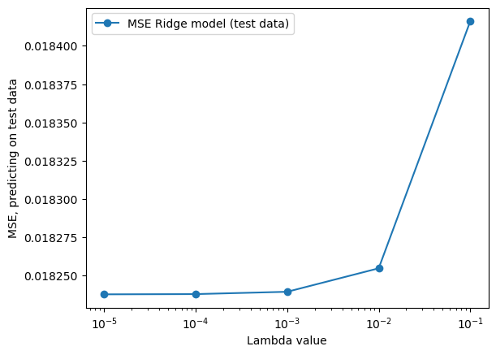

```python
# Define degree and lambdas
degree = 3
lam = np.logspace(-1, -5, num=5)
# Define empty MSE array
MSE_lam = np.zeros(len(lam))

# Split data
x_train, x_test, y_train, y_test = train_test_split(x, y, test_size=0.2)

# Feature matrices
X_train = polynomial_features(x_train, degree)
X_test = polynomial_features(x_test, degree)

# Scale data
scaler = StandardScaler()
scaler.fit(X_train)
X_train_s = scaler.transform(X_train)
X_test_s = scaler.transform(X_test)
y_offset = np.mean(y_train)

# Looping over lambdas
for i in lam:
    # Estimate parameters
    beta = Ridge_parameters(X_train_s, y_train, i)
    # Predict on test data
    y_test_pred = X_test_s @ beta + y_offset
    # Compute MSE on test data
    MSE_lam[int(abs(np.log10(i))-1)] = mean_squared_error(y_test, y_test_pred)

# Plotting
plt.plot(lam, MSE_lam, marker="o", label="MSE Ridge model (test data)")
plt.xlabel("Lambda value")
plt.ylabel("MSE, predicting on test data")
plt.xscale("log")
plt.legend()
plt.show()
```

```python
print(abs(np.log10(0.01))-1)
```

```
1.0
```

**c)**

```
[1.e-01 1.e-02 1.e-03 1.e-04 1.e-05]
```

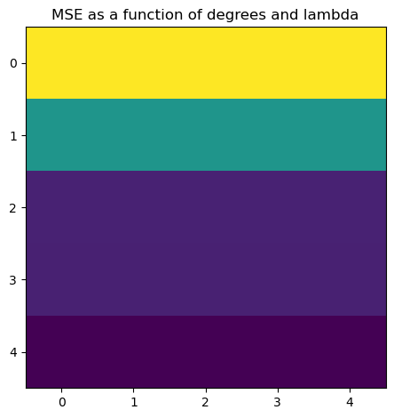

```python
# Define lists of degree values and lambda values
degrees = np.arange(1, 6)
lambdas = np.logspace(-1, -5, num=5)
print(lambdas)
# Define empty MSE matrix. Degrees on rows, lambdas on columns
MSE = np.zeros((len(degrees), len(lambdas)))


# Split data
x_train, x_test, y_train, y_test = train_test_split(x, y, test_size=0.2)


# Looping over lamdas and degrees
for deg in degrees:
    # Make feature matrices:
    X_train = polynomial_features(x_train, deg)
    X_test = polynomial_features(x_test, deg)
    # Scale data
    scaler = StandardScaler()
    scaler.fit(X_train)
    X_train_s = scaler.transform(X_train)
    X_test_s = scaler.transform(X_test)
    y_offset = np.mean(y_train)

    for lam in lambdas:
        # Estimate parameters
        beta = Ridge_parameters(X_train_s, y_train, lam)
        # Predict on test data
        y_test_pred = X_test_s @ beta + y_offset
        # Compute MSE on test data
        MSE[deg - 1, int(abs(np.log10(lam)))-1] = mean_squared_error(y_test, y_test_pred)



# Make heatmap
fig, ax = plt.subplots()
im = ax.imshow(MSE)
ax.set_title("MSE as a function of degrees and lambda")
fig.tight_layout()
plt.show()

#print(MSE)
```

In this case, the resolution in the heatmap is too small, so it is easier to present the data as a table:

```python
import pandas as pd
df = pd.DataFrame(MSE, degrees, lambdas)
display(df)

print("Lambda values on columns, polynomal degrees on rows")
```

|  | 0.10000 | 0.01000 | 0.00100 | 0.00010 | 0.00001 |
| --- | --- | --- | --- | --- | --- |
| 1 | 0.098858 | 0.098985 | 0.098998 | 0.098999 | 0.098999 |
| 2 | 0.057790 | 0.057851 | 0.057857 | 0.057857 | 0.057858 |
| 3 | 0.021362 | 0.021136 | 0.021114 | 0.021112 | 0.021111 |
| 4 | 0.020985 | 0.020841 | 0.020828 | 0.020827 | 0.020827 |
| 5 | 0.012991 | 0.013209 | 0.013251 | 0.013255 | 0.013256 |

```
Lambda values on columns, polynomal degrees on rows
```